# Analise paises

Marcelo Bracali

## Analise: Paises

O objetivo desse markdown é realizar uma analise em cima de uma base de paises e classificar os paises em grupos de acordo com a semelhança nas váriaves fornecidas. Essa base tem detalhado o desempenho de diversos paises em várias provas de resistência, cada uma das provas é representada por uma coluna.

Para tal o primeiro passo é importar a base e verificar o formato das variaveis:

```r
paises <- read.csv("C:/2019_workspace/2_PROJETOS/8_PORTIFOLIOS/Base Paises/DADOS_Papercsv_1.csv", row.names=1, sep=";")
str(paises) #Verificando o formato das variáveis
```

```
## 'data.frame':    54 obs. of  7 variables:
##  $ p100ms : num  11.6 11.1 11.2 11.1 11.5 ...
##  $ p200ms : num  22.9 22.2 22.7 22.5 23.1 ...
##  $ p400ms : num  52.5 48.6 50.6 51.5 53.3 ...
##  $ p800mm : num  2.05 1.98 1.94 1.97 2.07 1.97 1.97 2 1.93 2.04 ...
##  $ p1500mm: num  4.25 4.02 4.05 4.08 4.29 4.17 4 4.22 3.84 4.34 ...
##  $ p3000mm: num  9.19 8.63 8.78 8.82 9.81 9.04 8.54 9.26 8.1 9.37 ...
##  $ pmaratm: num  150 144 154 143 174 ...
```

```r
summary(paises) #Estatísticas descritivas
```

```
##      p100ms          p200ms          p400ms          p800mm
##  Min.   :10.49   Min.   :21.34   Min.   :47.60   Min.   :1.890
##  1st Qu.:11.12   1st Qu.:22.57   1st Qu.:49.97   1st Qu.:1.970
##  Median :11.32   Median :22.98   Median :51.65   Median :2.005
##  Mean   :11.36   Mean   :23.12   Mean   :51.99   Mean   :2.022
##  3rd Qu.:11.57   3rd Qu.:23.61   3rd Qu.:53.12   3rd Qu.:2.070
##  Max.   :12.52   Max.   :25.91   Max.   :61.65   Max.   :2.290
##     p1500mm         p3000mm          pmaratm
##  Min.   :3.840   Min.   : 8.100   Min.   :135.2
##  1st Qu.:4.003   1st Qu.: 8.543   1st Qu.:143.5
##  Median :4.100   Median : 8.845   Median :148.4
##  Mean   :4.189   Mean   : 9.081   Mean   :153.6
##  3rd Qu.:4.338   3rd Qu.: 9.325   3rd Qu.:157.7
##  Max.   :5.420   Max.   :13.120   Max.   :221.1
```

A titulo observatório, vamos ver a distribuição dos dados em cada uma das provas:

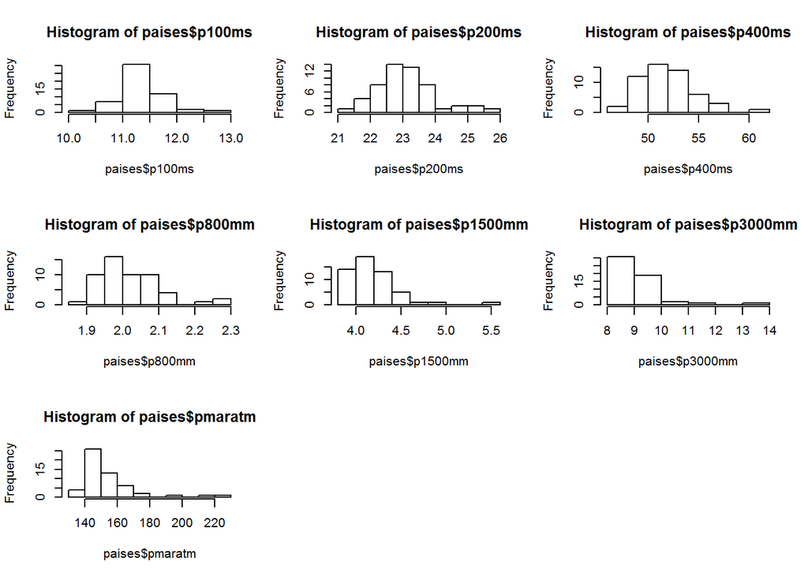

```r
par (mfrow=c(3,3))
hist(paises$p100ms)
hist(paises$p200ms)
hist(paises$p400ms)
hist(paises$p800mm)
hist(paises$p1500mm)
hist(paises$p3000mm)
hist(paises$pmaratm)
```

Ainda, é importante entender a correlação dos dados entre eles mesmos.

```r
matcor <- cor(paises)
print(matcor, digits = 2)
```

```
##         p100ms p200ms p400ms p800mm p1500mm p3000mm pmaratm
## p100ms    1.00   0.94   0.87   0.81    0.78    0.73    0.67
## p200ms    0.94   1.00   0.91   0.82    0.80    0.73    0.68
## p400ms    0.87   0.91   1.00   0.81    0.72    0.67    0.68
## p800mm    0.81   0.82   0.81   1.00    0.91    0.87    0.85
## p1500mm   0.78   0.80   0.72   0.91    1.00    0.97    0.79
## p3000mm   0.73   0.73   0.67   0.87    0.97    1.00    0.80
## pmaratm   0.67   0.68   0.68   0.85    0.79    0.80    1.00
```

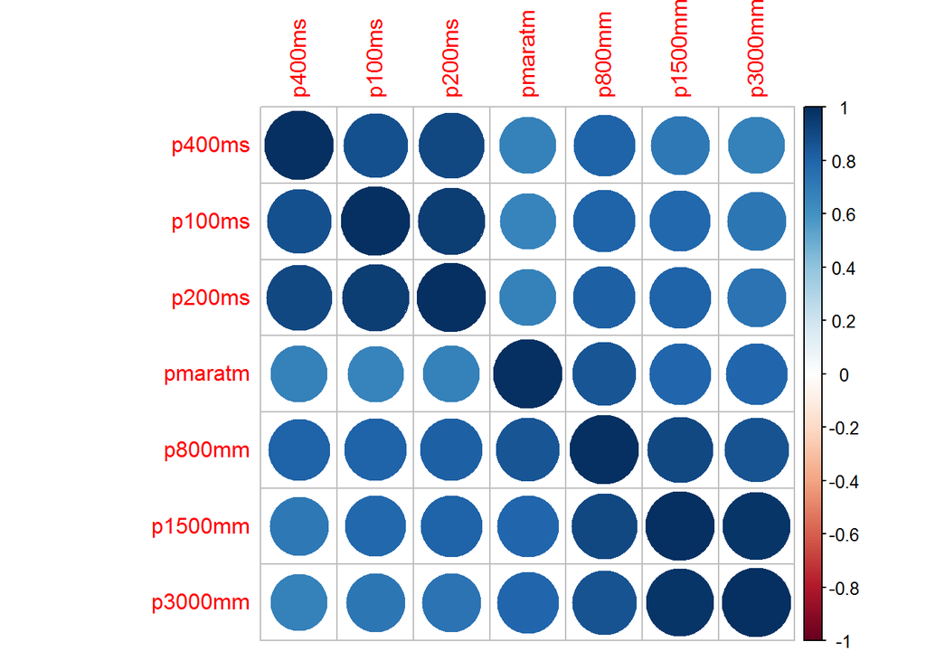

```r
#install.packages("corrplot")
library(corrplot)
corrplot::corrplot(matcor, method="circle", order="hclust")
```

```r
panel.cor <- function(x, y, digits=2, prefix ="", cex.cor,
    ...)  {
    usr <- par("usr")
    on.exit(par(usr))
    par(usr = c(0, 1, 0, 1))
    r <- cor(x, y , use = "pairwise.complete.obs")
    txt <- format(c(r, 0.123456789), digits = digits) [1]
    txt <- paste(prefix, txt, sep = "")
    if (missing(cex.cor))
        cex <- 0.8/strwidth(txt)
# abs(r) é para que na saída as correlações ficam proporcionais
    text(0.5, 0.5, txt, cex = cex * abs(r))
}
```

## Criando cluster de performance

Para a criação de clusters vamos utilizar uma técnica para deixar os dados escalaveis:

```r
Padr_paises <- scale(paises) # Aplica a técnica de SCALE
summary(Padr_paises) # Exibe estatisticas dos dados com a técnica ja aplicada
```

```
##      p100ms             p200ms            p400ms            p800mm
##  Min.   :-2.20192   Min.   :-1.9144   Min.   :-1.6899   Min.   :-1.5241
##  1st Qu.:-0.59700   1st Qu.:-0.5904   1st Qu.:-0.7784   1st Qu.:-0.6033
##  Median :-0.08317   Median :-0.1491   Median :-0.1325   Median :-0.2004
##  Mean   : 0.00000   Mean   : 0.0000   Mean   : 0.0000   Mean   : 0.0000
##  3rd Qu.: 0.53215   3rd Qu.: 0.5290   3rd Qu.: 0.4345   3rd Qu.: 0.5478
##  Max.   : 2.94905   Max.   : 3.0047   Max.   : 3.7197   Max.   : 3.0803
##     p1500mm           p3000mm           pmaratm
##  Min.   :-1.2830   Min.   :-1.2029   Min.   :-1.1174
##  1st Qu.:-0.6864   1st Qu.:-0.6602   1st Qu.:-0.6167
##  Median :-0.3284   Median :-0.2891   Median :-0.3156
##  Mean   : 0.0000   Mean   : 0.0000   Mean   : 0.0000
##  3rd Qu.: 0.5436   3rd Qu.: 0.2996   3rd Qu.: 0.2461
##  Max.   : 4.5180   Max.   : 4.9542   Max.   : 4.1071
```

Com os dados escalados vamos utilizar o Elbow Method para definir a quantidade de clusters

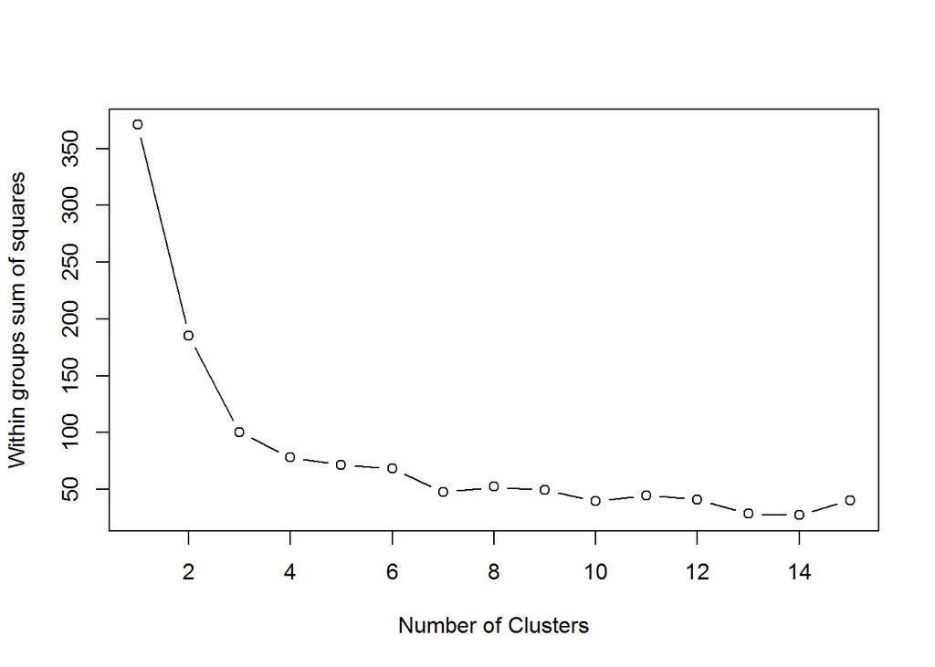

```r
wss <- (nrow(Padr_paises )-1)*sum(apply(Padr_paises ,2,var))
for (i in 2:15) wss[i] <- sum(kmeans(Padr_paises ,iter.max=100,
                                     centers=i)$withinss)
plot(1:15, wss, type="b", xlab="Number of Clusters",
     ylab="Within groups sum of squares")
```

Dada a curva, vamos seguir com 5 clusters para a criação de grupos. Agora vamos criar os grupos e entender sua representação de forma gráfica:

```r
#install.packages("tclust")
library(tclust)
```

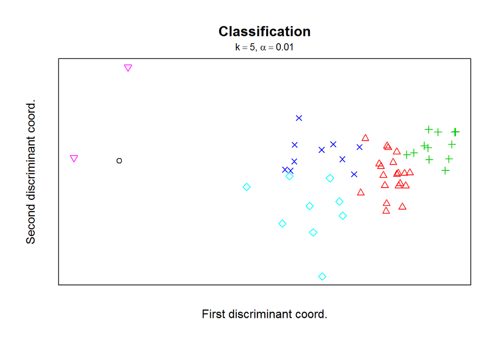

```r
clus_teste <- tkmeans(Padr_paises , k = 5, alpha = 0.01)
plot(clus_teste)
```

O R também fornece por padrão o algoritimo kmeans, vamos utiliza-lo também para verificar em qual cluster cada pais se encontra e ainda por final entender quantos paises estão dentro de cada cluster:

```r
#attach(Padr_paises)
set.seed(333)
output_cluster<-kmeans(Padr_paises,5,iter=100)
output_cluster
```

```
## K-means clustering with 5 clusters of sizes 9, 3, 12, 20, 10
##
## Cluster means:
##       p100ms     p200ms     p400ms     p800mm    p1500mm    p3000mm
## 1  0.9783162  1.0827754  1.0750173  0.4966805  0.5078968  0.2975403
## 2  2.3569809  2.3983714  2.2052936  2.8500509  2.8046512  2.9386078
## 3 -1.0833372 -1.1411799 -1.1383690 -0.9773735 -0.8271171 -0.7286330
## 4 -0.2569842 -0.2314452 -0.2441374 -0.3960654 -0.4917828 -0.4712720
## 5  0.2263942  0.1382970  0.2252139  0.6629513  0.6776037  0.6675350
##      pmaratm
## 1  0.1071693
## 2  3.3291417
## 3 -0.6404700
## 4 -0.4289115
## 5  0.5311920
##
## Clustering vector:
##   ARG   AUS   AUT   BEL   BER   BRA   CAN   CHI   CHN   COL   COK   CRC
##     5     3     4     4     5     4     3     1     3     5     2     5
##   CZE   DEN   DOM   FIN   FRA   GER   GBR   GRE   GUA   HUN   INA   IND
##     3     4     5     4     3     3     3     4     1     4     1     4
##   IRL   ISR   ITA   JPN   KEN KOR,S KOR,N   LUX   MAS   MRI   MEX   MYA
##     4     5     4     4     4     1     1     1     5     1     4     1
##   NED   NZL   NOR   PNG   PHI   POL   POR   ROM   RUS   SAM   SIN   ESP
##     4     4     4     2     5     3     4     3     3     2     1     3
##   SWE   SUI   TPE   THA   TUR   USA
##     4     4     5     5     4     3
##
## Within cluster sum of squares by cluster:
## [1] 14.180655 18.777899  8.615614 14.758028 10.641881
##  (between_SS / total_SS =  81.9 %)
##
## Available components:
##
## [1] "cluster"      "centers"      "totss"        "withinss"
## [5] "tot.withinss" "betweenss"    "size"         "iter"
## [9] "ifault"
```

```r
segmento<-output_cluster$cluster
table (segmento)
```

```
## segmento
##  1  2  3  4  5
##  9  3 12 20 10
```

Com a clusterização feita, gostaria de mostrar uma forma um pouco mais visivel de enxergar os grupos

```r
#install.packages("cluster")
library(cluster)
```

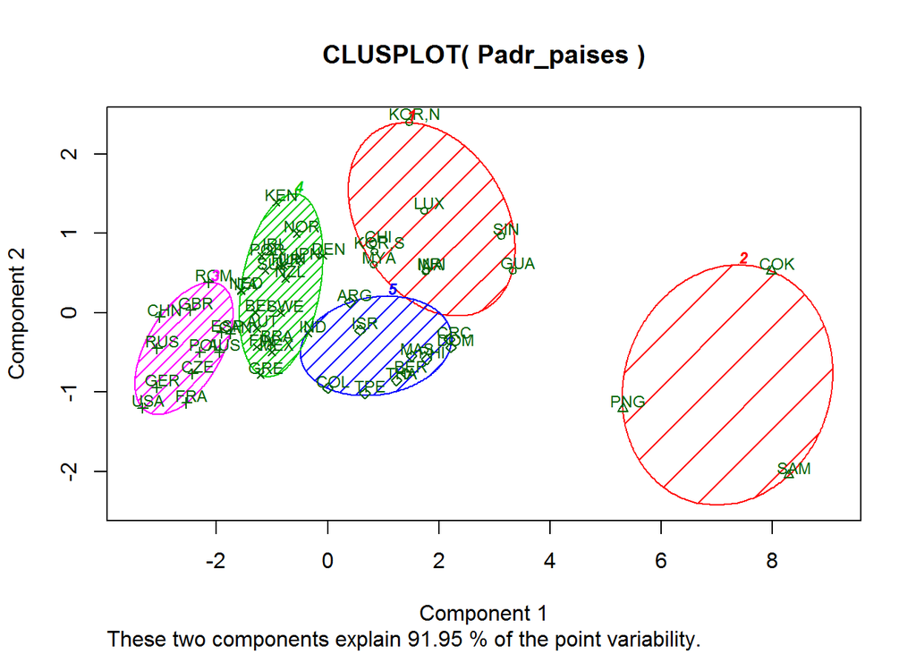

```r
clusplot(Padr_paises, output_cluster$cluster, color=TRUE, shade=TRUE,
         labels=2, lines=0 , cex=0.75)
```

Nesse ponto já temos todos os paises devidamente agrupados com seus “semelhantes”. Desse ponto em diante poderiamos definir uma série de próximos passos mas essa analise se limita a clusterização.